# Data Analysis Skill Test

Vinicius Ranieri

7/6/2020

## Overview

This is a file to demonstrate data analysis skills for 4intelligence Two cases will be analyzed, first one will look into total-factor productivity (TFP) for three countries: United States (USA), Canada (CAN) and Mexico (MEX) and the second case some analysis will be done on data from Comexstat, which is basically the official data source for brazilian exports e imports, maintened by the government.

## Case 1 -

The data anaylsis is focused to address the following questions and requests regarding the total-factor productivity (TFP) of three countries: United States (USA), Canada (CAN) and Mexico (MEX).

1. Make an exploratory data analysis;

2.Forecast 10 years of the series using package “forecast”);

3.Check in the following link pages 2 and 3: https://cran.r-project.org/web/packages/pwt8/pwt8.pdf to see a list of all variables in the original dataset. Can you think about another feature that could be helpful in explaining TFP series? Explain.

### Data processing aand pre-settings

During this exercise, the following libraries are required to run this code. Make sure to have then installed prior to running the code

```r
library(ggplot2)
library(forecast)
library(knitr)
library(kableExtra)
library(forecast)
library(xlsx)
library(GGally)
library(corrplot)
library(tidyverse)
library(lubridate)
library(ggpubr)
library(reshape)
```

First step is to load the data into a dataframe “df” and factor by country name.

```r
#Load data
df<-read.csv("TFP.csv")

df$isocode<-factor(df$isocode) #factor  country names
summary(df)
```

```
##  isocode       year          rtfpna
##  CAN:62   Min.   :1950   Min.   :0.6171
##  MEX:62   1st Qu.:1965   1st Qu.:0.8551
##  USA:62   Median :1980   Median :0.9950
##           Mean   :1980   Mean   :0.9756
##           3rd Qu.:1996   3rd Qu.:1.0463
##           Max.   :2011   Max.   :1.3837
```

Based on the summary above, it shows that there are similar amounts of data for each country, which minimizes the effects of bias in the data in case some statistical metrics.

### Exploratory analysis

A histogram can show if the data is follows a normal distribution. The library ggplo2 2 is going to be used to generate the charts in this file.

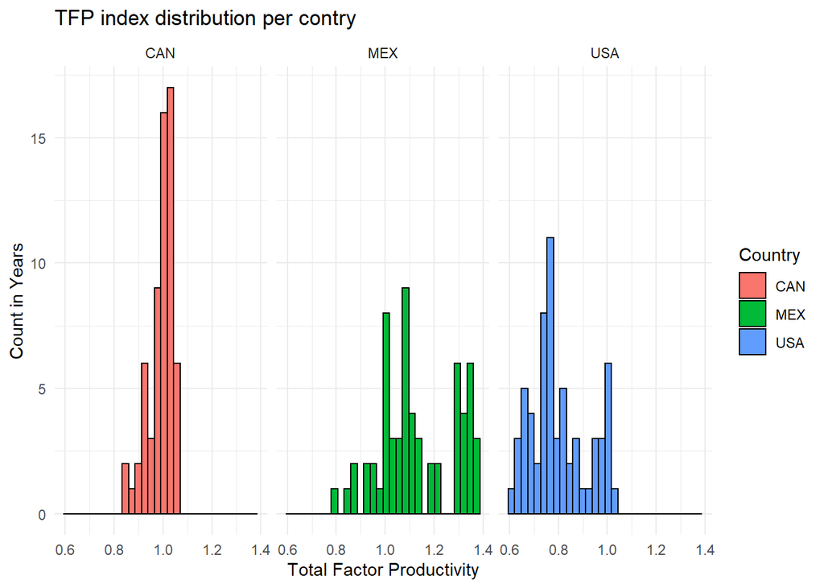

```r
ggplot(df,aes(x=rtfpna,fill=isocode))+ facet_wrap(~isocode)+
  geom_histogram(color="black")+labs(title = "TFP index distribution per contry")+
    labs(x="Total Factor Productivity",y="Count in Years",fill = "Country")+ theme_minimal()
```

Looking at the histogram, the data does not seems to be follow a normal distribution.

Let´s see how the TPF evolved along the years through a time series chart.

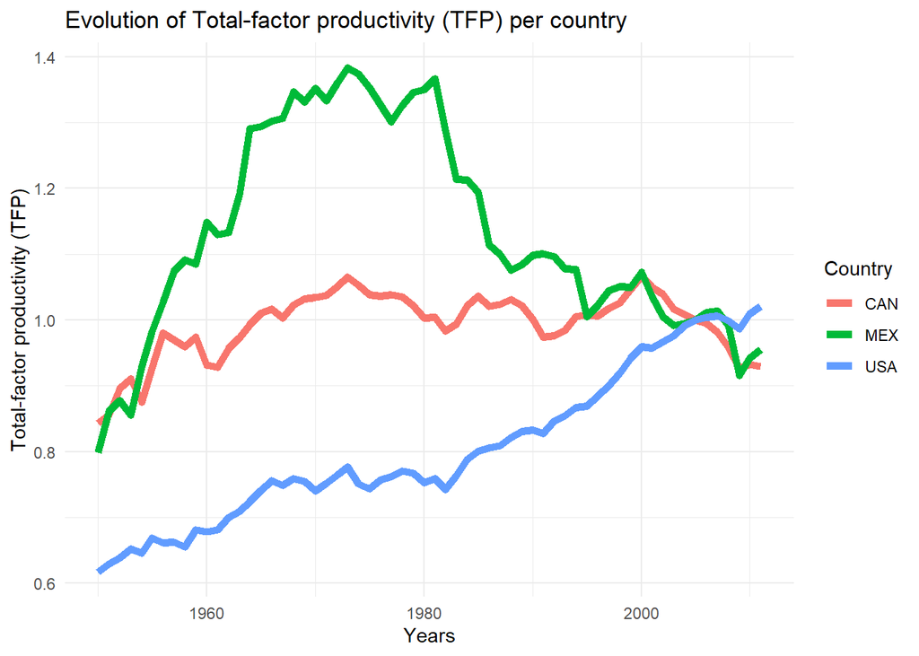

```r
ggplot(df,aes(x=year, y=rtfpna))+
     geom_line(aes(color = isocode),size=2)+
    labs(title = "Evolution of Total-factor productivity (TFP) per country")+
    labs(y="Total-factor productivity (TFP)")+labs(x="Years")+
    labs( color = "Country")+ theme_minimal()
```

Data series are usually composed by a trend, a seasonal and a remainder. Looking at the chart it is really hard to find any seasonal component,while a clear increasing trend on USA data can be noticed.

### 10 years Time Series predicition

To perform a 10 year prediction for each country, we need to convert the data type into a time Series which is required for the forecast() R package. A multivariable timeseries will be created with one colunm per country and one column with time data(year in this case). the code below does that conversion.

```r
#Reshape data grouping the TFP by date and Country
df_reshape <- reshape(data=df,idvar="year",
                           v.names = "rtfpna",
                           timevar = "isocode",
                          direction="wide")

#convert df_reshape into time series(ts1), Frequency=1 means one row per year startin
#Frequency=1 means one row per year starting in 1950
ts1<-ts(df_reshape[,2:4],start=1950,frequency=1)

#Assign Colonm names
colnames(ts1)=unique(df$isocode)
head(ts1)
```

```
## Time Series:
## Start = 1950
## End = 1955
## Frequency = 1
##            USA       CAN       MEX
## 1950 0.6171479 0.8433348 0.7981593
## 1951 0.6295884 0.8551230 0.8609314
## 1952 0.6384513 0.8964893 0.8769677
## 1953 0.6518582 0.9106582 0.8552045
## 1954 0.6461794 0.8751778 0.9291679
## 1955 0.6687729 0.9276822 0.9818486
```

The forecast function is going to be used to predict the time series values at a certain time in future. It will choose the algorithm automatically which could be dangerous in some situations.The forecast library is required for this prediction.

```r
# Forecast 10 years ahead of current data
ts1f<-forecast(ts1,h=10)

# Display the methodology used for the prediction
ts1f$method
```

```
##           USA           CAN           MEX
##  "ETS(A,A,N)"  "ETS(A,N,N)" "ETS(M,Ad,N)"
```

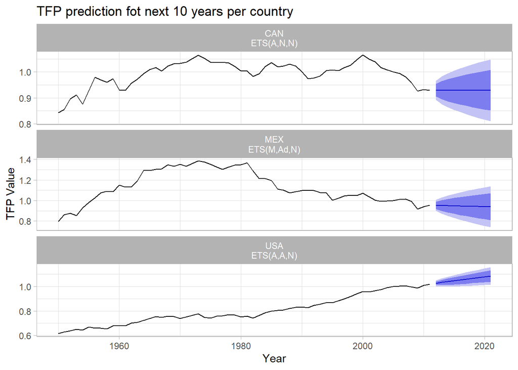

```r
#Predicted data series Plot
autoplot(ts1f)+labs(x="Year",y="TFP Value", title="TFP prediction fot next 10 years per country")+
    theme_light()
```

Let´s take a look into prediction and its corresponds confidence intervals.

```r
#Extract prediction and confidence intervals from forecast object

USA<-as.data.frame(ts1f$forecast[1])
CAN<-as.data.frame(ts1f$forecast[2])
MEX<-as.data.frame(ts1f$forecast[3])
colnames(USA)<-c("Forecast","Lo80%","Hi80%","Lo95%","Hi95%")
colnames(CAN)<-c("Forecast","Lo80%","Hi80%","Lo95%","Hi95%")
colnames(MEX)<-c("Forecast","Lo80%","Hi80%","Lo95%","Hi95%")

kable(cbind(USA,CAN,MEX)[,c(1,4,5,6,9,10,11,14,15)],
      caption = "USA TFP prediction for next 10 years",
      booktabs = T, digits = 3) %>%
    kable_styling(c("bordered","striped"), full_width = T) %>%
    add_header_above(c("Year ", "USA" = 3, "CAN" = 3, "MEX 3" = 3))
```

| Year | USA Forecast | USA Lo95% | USA Hi95% | CAN Forecast.1 | CAN Lo95%.1 | CAN Hi95%.1 | MEX 3 Forecast.2 | MEX 3 Lo95%.2 | MEX 3 Hi95%.2 |
| --- | --- | --- | --- | --- | --- | --- | --- | --- | --- |
| 2012 | 1.027 | 1.004 | 1.050 | 0.929 | 0.892 | 0.967 | 0.954 | 0.898 | 1.009 |
| 2013 | 1.034 | 1.001 | 1.066 | 0.929 | 0.876 | 0.983 | 0.952 | 0.871 | 1.032 |
| 2014 | 1.040 | 1.001 | 1.079 | 0.929 | 0.864 | 0.995 | 0.950 | 0.850 | 1.050 |
| 2015 | 1.047 | 1.001 | 1.092 | 0.929 | 0.854 | 1.005 | 0.948 | 0.831 | 1.065 |
| 2016 | 1.053 | 1.003 | 1.104 | 0.929 | 0.845 | 1.014 | 0.946 | 0.814 | 1.079 |
| 2017 | 1.060 | 1.004 | 1.115 | 0.929 | 0.837 | 1.022 | 0.945 | 0.797 | 1.093 |
| 2018 | 1.066 | 1.006 | 1.126 | 0.929 | 0.830 | 1.029 | 0.944 | 0.782 | 1.105 |
| 2019 | 1.073 | 1.009 | 1.137 | 0.929 | 0.823 | 1.036 | 0.942 | 0.768 | 1.117 |
| 2020 | 1.080 | 1.012 | 1.148 | 0.929 | 0.816 | 1.043 | 0.941 | 0.754 | 1.129 |
| 2021 | 1.086 | 1.014 | 1.158 | 0.929 | 0.810 | 1.049 | 0.940 | 0.740 | 1.140 |

### Further investigation about TFP

From the charts we could notice that Mexico has a declining trend, Canada is more or less stable with a decline trend in the past year while USA is in a growth trend. To better understand the reasons why, we first need to look into TFP definition to identify what other variables affect this numbers. According to the [Capital, labor and TFP in PWT 8.0](https://www.rug.nl/ggdc/docs/capital_labor_and_tfp_in_pwt80.pdf), Productivity is, in general, a measure of output divided by a measure of input.Here, we are interested in country-level productivity,so GDP as the measure of output and capital and labor as inputs.

A general production function combining capital K and labor input L with a level of productivity A to produce output Y is given below.

Y = Af (K,L) = AKα (Ehc)^1−α

The second equality defines labor input as the product of the number of workers in the economy **E** times their average human capital **hc**; introduces **α** as the output elasticity of capital, as an proximation, **α** is assumed as the share of GDP that is not earned by labor. Therefore we should look into those variables to understand what is driving the TFP changes.

Looking at the other variables available in the original dataset, and that the TFP is based on at constant national prices(2005=1), we should look into:

- **rgdpna** - Real GDP at constant 2005 national prices (in million 2005 USD)
- **rkna** - Capital stock at constant 2005 national prices (in million 2005 USD) and
- **emp** - Number of persons engaged (in millions)

**labsh** Share of labour compensation in GDP at current national prices

**hc** Index of human capital per person, based on years of schooling (Barro and Lee 2013) and returns to education (Psacharopoulos 1994).

## Case 2

On this exercise some analysis will be performaned with data from Comexstat, official data source for brazilian exports e imports, maintened by the government.

There are 6 questions to be addressed in this exercise

1.Show the evolution of total monthly and total annual exports from Brazil (all states and to everywhere) of ‘soybeans’, ‘soybean oil’ and ‘soybean meal’;

2.What are the 3 most important products exported by Brazil in the last 5 years?

3.What are the main routes through which Brazil have been exporting ‘corn’ in the last few years? Are there differences in the relative importancem of routes depending on the product?

4.Which countries have been the most important trade partners for Brazil in terms of ‘corn’ and ‘sugar’ in the last 3 years?

5.For each of the products in the dataset, show the 5 most important states in terms of exports?

6.Now, we ask you to show your modelling skills. Feel free to use any type of modelling approach, but bear in mind that the modelling approach depends on the nature of your data, and so different models yield different estimates and forecasts. To help you out in this task we also provide you with a dataset of possible covariates (.xlsx). They all come from public sources (IMF, World Bank) and are presented in index number format. Question: What should be the total brazilian soybeans, soybean_meal, and corn export forecasts, in tons, for the next 11 years (2020-2030)? We’re mostly interested in the annual forecast.

### Data processing aand pre-settings

First step is to load the data into a dataframe “df2”, and convert the date into a Date class. A Summary of df is provided below

```r
df2<-read.csv("data_comexstat.csv",stringsAsFactors = T)
df2$date=as.Date(df2$date,format = "%Y-%m-%d")
summary(df2)
```

```
##       date                    product          state
##  Min.   :1997-01-01   corn        :21872   SP     :28713
##  1st Qu.:2007-02-01   soybean_meal:18215   PR     :17155
##  Median :2012-10-01   soybean_oil :16116   MT     :16837
##  Mean   :2011-06-24   soybeans    :22914   GO     :10981
##  3rd Qu.:2016-09-01   sugar       :35202   RS     : 8147
##  Max.   :2019-12-01   wheat       : 3646   MG     : 7983
##                                            (Other):28149
##           country          type           route            tons
##  China        : 7437   Export:105861   Air   : 2918   Min.   :      0.0
##  Paraguay     : 7160   Import: 12104   Ground:13038   1st Qu.:    124.9
##  Netherlands  : 7158                   Other : 6374   Median :   2000.0
##  Argentina    : 4842                   River : 1765   Mean   :  14536.8
##  Spain        : 3777                   Sea   :93870   3rd Qu.:  13534.0
##  United States: 3717                                  Max.   :1798445.6
##  (Other)      :83874
##       usd
##  Min.   :        0
##  1st Qu.:    71552
##  Median :   725000
##  Mean   :  4813150
##  3rd Qu.:  3895943
##  Max.   :903930411
##
```

Second step is to add all volume and income from same day, differentiating by product, type and date.

To answer some of the questions will also be required to subset data by month and year, so month and year will be added as variables

```r
# Aggregate by product, type and date
df2agg<-aggregate(list(tons = df2$tons, usd=df2$usd), by = list(
    date=df2$date,product = df2$product,type=df2$type),FUN=sum)


#Add Month and year as variables
df2agg$year <- year(df2agg$date)
df2agg$month <- factor(month(df2agg$date,label=TRUE,abbr=TRUE))
summary(df2agg)
```

```
##       date                    product        type           tons
##  Min.   :1997-01-01   corn        :552   Export:1513   Min.   :       0
##  1st Qu.:2003-04-08   soybean_meal:540   Import:1485   1st Qu.:    1925
##  Median :2009-04-01   soybean_oil :540                 Median :   80631
##  Mean   :2008-12-16   soybeans    :537                 Mean   :  571993
##  3rd Qu.:2014-10-01   sugar       :550                 3rd Qu.:  577739
##  Max.   :2019-12-01   wheat       :279                 Max.   :12325914
##
##       usd                 year          month
##  Min.   :5.000e+00   Min.   :1997   Dec    : 254
##  1st Qu.:8.460e+05   1st Qu.:2003   Mar    : 251
##  Median :1.686e+07   Median :2009   Aug    : 251
##  Mean   :1.894e+08   Mean   :2009   Nov    : 251
##  3rd Qu.:1.538e+08   3rd Qu.:2014   Feb    : 250
##  Max.   :4.987e+09   Max.   :2019   May    : 250
##                                     (Other):1491
```

### Data analysis

#### Soybeans, Soybean oil and soybean meal total monthly and total annual exports from Brazil evolution.

To get the answer the question it is required to Subset the data looking only to export soybeans,soybean_meal,soybean_oil income. For annual exports, the sum of all volume and income from the year will be added

```r
#Subset by export and products
df3 = df2agg[df2agg$product %in%c("soybeans","soybean_meal","soybean_oil") & df2agg$type=="Export",]

#Calculate year productions
df3year<-aggregate(list(tons = df3$tons, usd=df3$usd), by = list(
    date=df3$year,product = df3$product),FUN=sum)
```

Let´s take a look into some charts

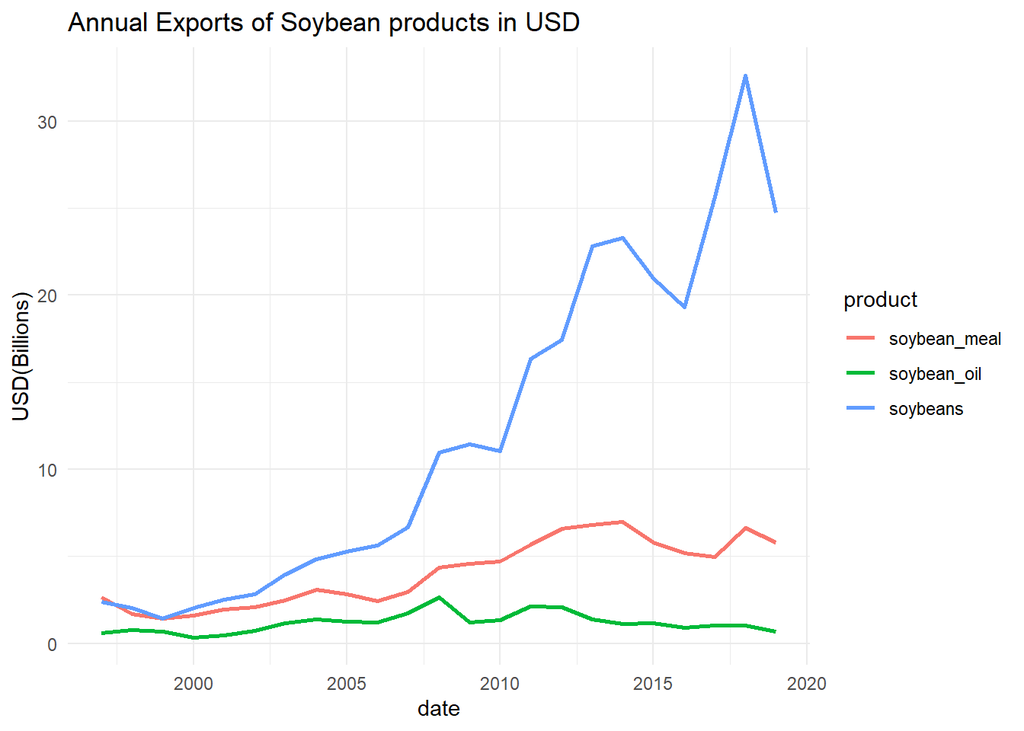

```r
#Line chart
ggplot(df3year,aes(x=date,y=usd/10^9))+geom_line(aes(color = product),size=1)+
    labs(title = "Annual Exports of Soybean products in USD",y="USD(Billions)")+
    theme_minimal()
```

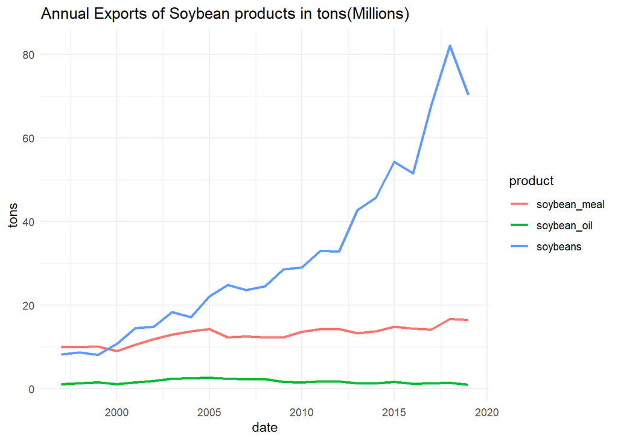

```r
ggplot(df3year,aes(x=date,y=tons/10^6))+geom_line(aes(color = product),size=1)+
    labs(title = "Annual Exports of Soybean products in tons(Millions)",y="tons")+
    theme_minimal()
```

We can notice the the soybean had a boom in the past years, not followed by the others products

For the monthly exports I going to use the box plot, so we can also check the variance and some seasonality of the data I also would take advantage of same R packages to show the seasonality, which is required to create a timeseries object

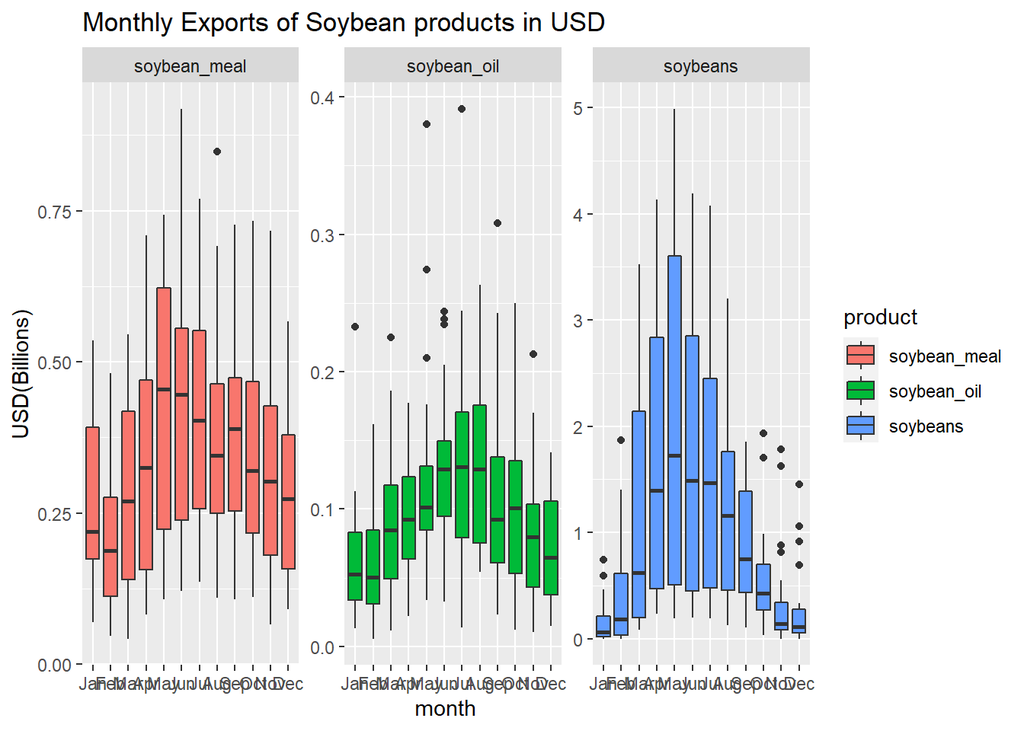

```r
#box plot
ggplot(df3, aes(x=month, y=usd/10^9,fill=product)) +
    geom_boxplot() +
    facet_wrap(~product,scales = "free")+
    labs(title = "Monthly Exports of Soybean products in USD",y="USD(Billions)")
```

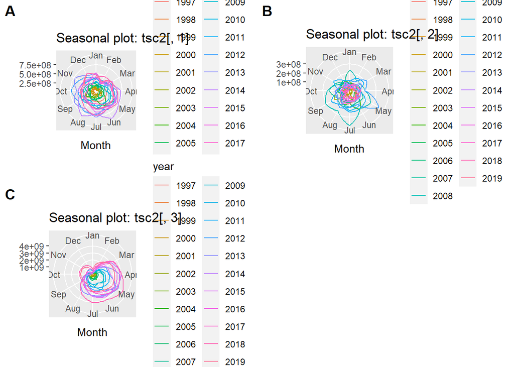

```r
#Reshape data to create a new time series
temp <- reshape(data=df3,idvar="date",drop = c("tons","year","month","type"),
                           v.names = "usd",timevar = "product",
                          direction="wide")


#Time series
tsc2<-ts(temp[,2:4],start=c(1997,1),frequency=12)
colnames(tsc2)=unique(df3$product)

p1<-ggseasonplot(tsc2[,1],polar = T)
p2<-ggseasonplot(tsc2[,2],polar = T)
p3<-ggseasonplot(tsc2[,3],polar = T)
figure <- ggarrange(p1, p2, p3,
                    labels = c("A", "B", "C"),
                    ncol = 2, nrow = 2)
figure
```

We can see that data is seasonal, with more export during the winter. Also it is noticed taht soybeans has much more variability

### Most important products in the past 5 years

In this case we need to take data starting at 2015

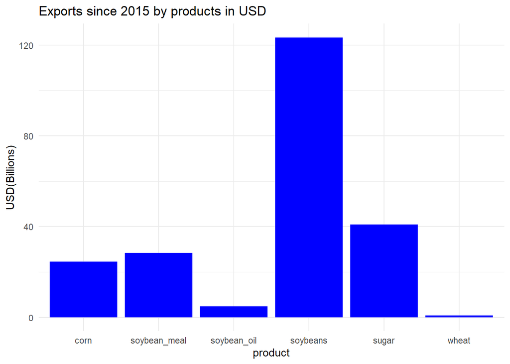

```r
#Take export data starting at 2015, Aggregate by year and product
df4 = df2agg[df2agg$type=="Export"& df2agg$date>=as.Date('2015-01-01'),]
df4year<-aggregate(list(tons = df4$tons, usd=df4$usd), by = list(
    date=df4$year,product = df4$product),FUN=sum)


ggplot(df4year,aes(x=product,y=usd/10^9))+geom_bar(stat="identity",fill = "blue")+
    labs(title = "Exports since 2015 by products in USD",y="USD(Billions)")+
    theme_minimal()
```

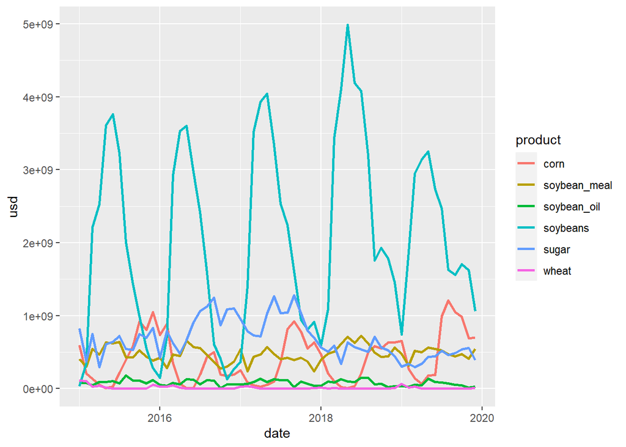

```r
ggplot(df4,aes(x=date,y=usd))+geom_line(aes(color = product),size=1)
```

From that chart we can see that soybeans, sugar and soybeans meal are the 3 most important products in terms of export revenue;

### Corn Export Main routes

Let´s look into the routs that corn has been exported in the past 3 years. This time data will be aggregated by route

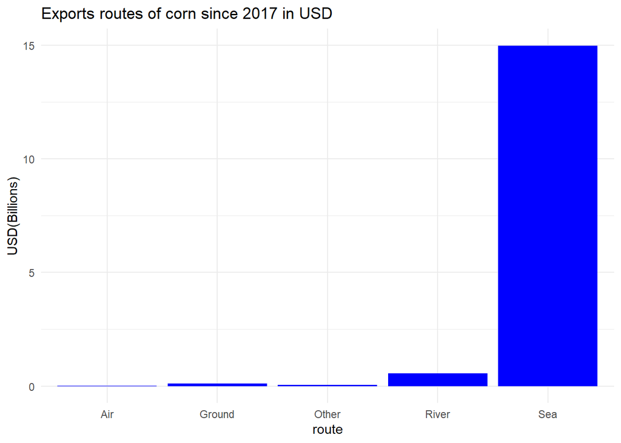

```r
#aggregate by route,product.type and date.
corn_agg<-aggregate(list(tons = df2$tons, usd=df2$usd), by = list(
    date=df2$date,product = df2$product,type=df2$type,route=df2$route),FUN=sum)
#filter data for Export in the past 3 years
corn_fil<-filter(corn_agg,type=="Export",product=="corn",date>=('2017-01-01'))

#Sum the total of exports by route
corn_route<-aggregate(list(usd=corn_fil$usd), by = list(
    route = corn_fil$route),FUN=sum)

#plot data
ggplot(corn_route,aes(x=route,y=usd/10^9))+geom_bar(stat="identity",fill = "blue")+
    labs(title = "Exports routes of corn since 2017 in USD",y="USD(Billions)")+
    theme_minimal()
```

It is clear that transportation by sea is the most used for corn

Let´s take a look into other products to see if the same patter is seen.

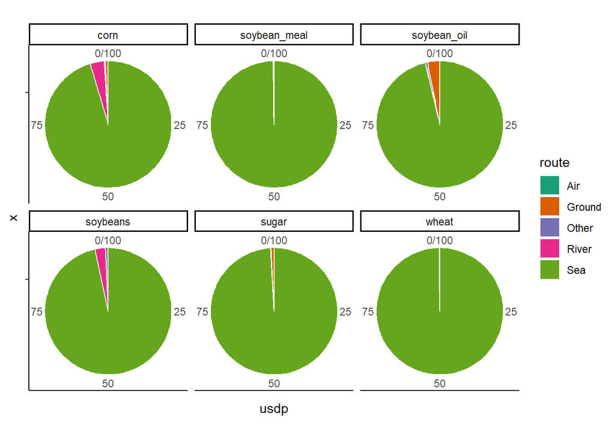

```r
# Select other products
fil<-filter(df2,type=="Export",date>=('2017-01-01'))
route<-aggregate(list(usd=fil$usd,tons=fil$tons), by = list(
    route = fil$route,product=fil$product),FUN=sum)



#Normalizing data to be displayed into the pie chart
z<-1
route$usdp<-route$usd
for(i in 1:length(unique(route$product))){
    tsum<-route$usd[route$product==unique(route$product)[i]]
                 for(j in 1:length(tsum)){
                     route$usdp[z]<-100*route$usd[z]/sum(tsum)
                     z<-z+1
                 }
}

#Pie Plot

ggplot(route,aes(x="",y=usdp,fill=route))+
     geom_bar(width = 1, stat = "identity", color = "white") +
    coord_polar("y",start = 0)+facet_wrap(.~factor(product))+
    scale_fill_brewer(palette="Dark2")+theme_classic()
```

```r
 labs(title = "Exports routes of corn since 2017 in USD",y="USD(Billions)")
```

```
## $y
## [1] "USD(Billions)"
##
## $title
## [1] "Exports routes of corn since 2017 in USD"
##
## attr(,"class")
## [1] "labels"
```

It become clear that all products are exported by sea, which makes senses as ship transportation is usualy the chapest one.

### Most importan partneres for Corn and Suggar

Let´s take a look into those variables, i will also include soybeans e soybeans_meal in the filter as they will to be used later on

```r
fil<-filter(df2,type=="Export",date>=('2017-01-01')& product %in% c("corn","sugar","soybeans","soybean_meal"))
partners<-aggregate(list(usd=fil$usd,tons=fil$tons), by = list(
        country = fil$country,product=fil$product),FUN=sum)

partners<-partners[order(-partners$usd),]
head(partners[partners$product=="sugar",],10)
```

```
##                  country product        usd    tons
## 268              Algeria   sugar 2176380928 6696854
## 278           Bangladesh   sugar 2063174600 6331640
## 333                India   sugar 1696094938 5111372
## 412 United Arab Emirates   sugar 1538397895 4545802
## 386         Saudi Arabia   sugar 1380455693 4249462
## 368              Nigeria   sugar 1336515029 4156814
## 336                 Iraq   sugar 1158541230 3555241
## 351             Malaysia   sugar 1039031070 2981729
## 308                Egypt   sugar 1010584065 3071224
## 360              Morocco   sugar  931580393 2850893
```

```r
head(partners[partners$product=="corn",],10)
```

```
##         country product        usd     tons
## 46         Iran    corn 2822336281 16425650
## 53        Japan    corn 1574975592  9676921
## 110     Vietnam    corn 1551035208  9446982
## 31        Egypt    corn 1375065136  8353797
## 94        Spain    corn 1335769607  8243941
## 93  South Korea    corn 1024567902  6273068
## 99       Taiwan    corn  815565313  5059363
## 61     Malaysia    corn  696333511  4238332
## 9    Bangladesh    corn  527878978  3228436
## 66       Mexico    corn  422359346  2519003
```

```r
head(partners[partners$product=="soybeans",],10)
```

```
##         country  product         usd      tons
## 210       China soybeans 66315629821 175692356
## 252       Spain soybeans  2253956830   6088717
## 255    Thailand soybeans  1677820148   4499915
## 234 Netherlands soybeans  1650380589   4444890
## 222        Iran soybeans  1516996293   4070650
## 245      Russia soybeans  1220809826   3085948
## 257      Turkey soybeans  1055033564   2858055
## 237    Pakistan soybeans   869848767   2349512
## 254      Taiwan soybeans   745462839   2026197
## 264     Vietnam soybeans   601863349   1625493
```

```r
head(partners[partners$product=="soybean_meal",],10)
```

```
##         country      product        usd    tons
## 165 Netherlands soybean_meal 3188803196 7670018
## 189    Thailand soybean_meal 2188293864 6187196
## 150   Indonesia soybean_meal 1696155560 4643851
## 184 South Korea soybean_meal 1690042508 4892688
## 140      France soybean_meal 1630161285 4823579
## 143     Germany soybean_meal 1483360136 3667139
## 182    Slovenia soybean_meal  902511166 2631311
## 197     Vietnam soybean_meal  684572041 1865783
## 151        Iran soybean_meal  605779901 1757117
## 185       Spain soybean_meal  592047169 1730263
```

Argelia and Blangadesh are the top importers of brazilian sugar with similar volumes. Iran is higher consumer of brazilian corner with almost 2 times more imports han Japan that comes in second

### Most Important states for each product

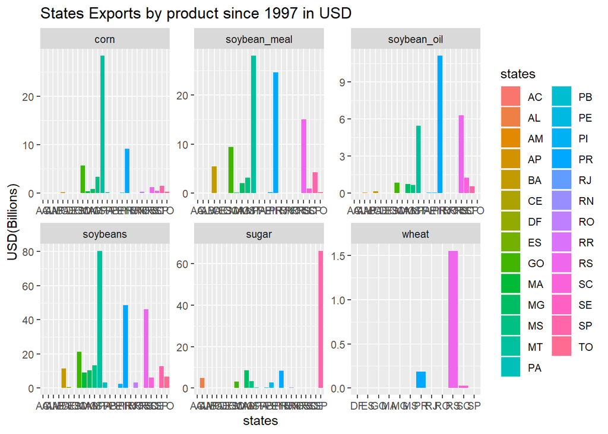

```r
fil<-filter(df2,type=="Export")
states<-aggregate(list(usd=fil$usd,tons=fil$tons), by = list(
        states = fil$state,product=fil$product),FUN=sum)

ggplot(states,aes(x=states,y=usd/10^9,fill=states))+
    geom_bar(stat= "identity", aes(fill = states))+
    facet_wrap(~product,scales = "free")+
    labs(title = "States Exports by product since 1997 in USD",y="USD(Billions)")
```

### Modeling

Let´s import the covariates data provided, and filter the export data by the products that we are interested on. Then the covariates data will be merged with the export data.

```r
#load covariate file
cov<-read.xlsx("covariates.xlsx",sheetIndex =1)


#filter data with desired products
fil<-filter(df2agg,type=="Export" & product %in% c("corn","soybeans","soybean_meal"))


#aggegate by year
prodyear<-aggregate(list(usd=fil$usd,tons=fil$tons), by = list(
        year = fil$year,product=fil$product),FUN=sum)

#reashape to merge
prodyear2<-cast(prodyear, year ~ product, mean, value = 'usd')


#merge data
df5<-merge(prodyear2,cov,by="year",all.x = FALSE)
```

Lets see the correlation beteween the variables

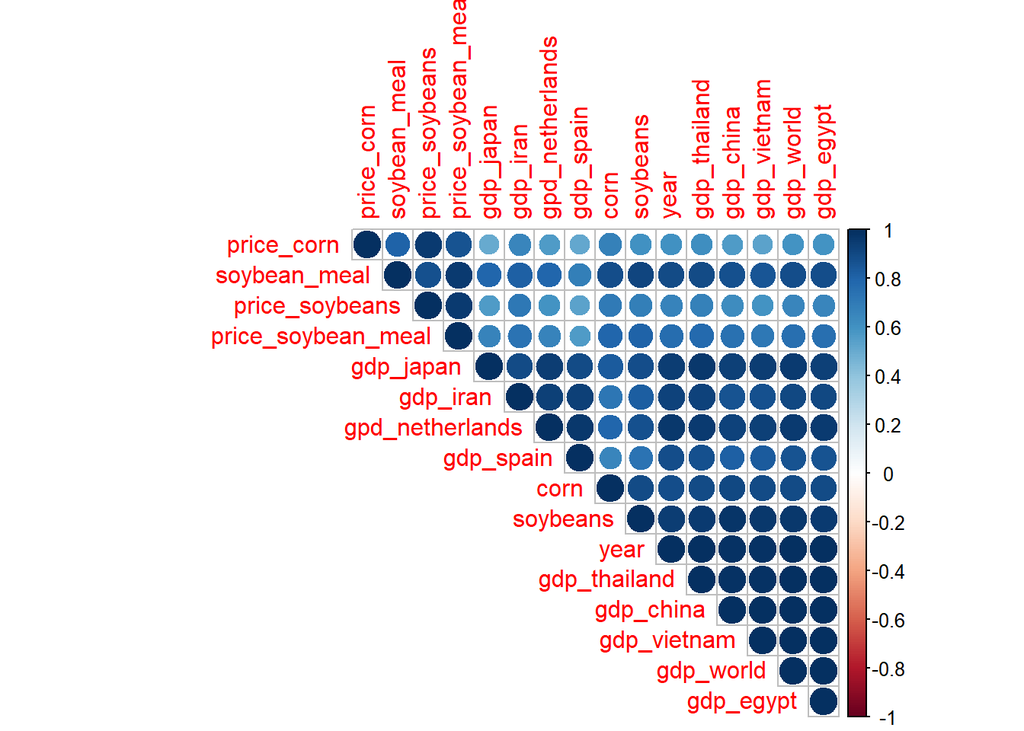

```r
M<-cor(df5)
# correlogram with hclust reordering
corrplot(M, type="upper", order="hclust")
```

This char shows which variables have more potential do have a strong relashiship with another,

A muultivariable linear regression will be performed fisrt all data is taken in consideration. Corn will be the first to be analyzed

```r
model_corn <- lm(corn ~ ., data = df5)
summary(model_corn)
```

```
##
## Call:
## lm(formula = corn ~ ., data = df5)
##
## Residuals:
##        Min         1Q     Median         3Q        Max
## -544936693 -100732835   23346426  109753602  704027328
##
## Coefficients:
##                      Estimate Std. Error t value Pr(>|t|)
## (Intercept)        -2.978e+12  8.529e+11  -3.492  0.01010 *
## year                1.495e+09  4.293e+08   3.482  0.01024 *
## soybean_meal       -1.595e+00  5.418e-01  -2.943  0.02161 *
## soybeans            5.953e-02  7.348e-02   0.810  0.44449
## price_soybeans      1.036e+07  3.159e+07   0.328  0.75265
## price_corn          2.379e+07  1.384e+07   1.719  0.12930
## price_soybean_meal  1.223e+07  2.904e+07   0.421  0.68633
## gdp_china           5.376e+06  1.171e+07   0.459  0.66001
## gdp_iran           -1.039e+08  2.540e+07  -4.090  0.00463 **
## gpd_netherlands    -1.186e+08  1.122e+08  -1.057  0.32565
## gdp_spain           1.562e+07  8.290e+07   0.188  0.85585
## gdp_thailand        2.169e+07  2.752e+07   0.788  0.45635
## gdp_world          -1.767e+08  1.330e+08  -1.328  0.22572
## gdp_egypt           3.497e+07  3.832e+07   0.913  0.39178
## gdp_japan           2.041e+08  1.270e+08   1.608  0.15192
## gdp_vietnam        -1.609e+07  2.023e+07  -0.795  0.45254
## ---
## Signif. codes:  0 '***' 0.001 '**' 0.01 '*' 0.05 '.' 0.1 ' ' 1
##
## Residual standard error: 4.18e+08 on 7 degrees of freedom
## Multiple R-squared:  0.9893, Adjusted R-squared:  0.9663
## F-statistic: 43.05 on 15 and 7 DF,  p-value: 2.017e-05
```

The goal is to get to a model where the last column is <0.05 in the first line and also the variables used in the correlation, which means that those variables has a strong relationship with the desired outcome(usd)

```r
model_corntop5 <- lm(corn ~ year+price_corn+gdp_iran+gdp_japan, data = df5)
summary(model_corntop5)
```

```
##
## Call:
## lm(formula = corn ~ year + price_corn + gdp_iran + gdp_japan,
##     data = df5)
##
## Residuals:
##        Min         1Q     Median         3Q        Max
## -1.241e+09 -2.407e+08  7.075e+07  2.122e+08  9.735e+08
##
## Coefficients:
##               Estimate Std. Error t value Pr(>|t|)
## (Intercept) -8.769e+11  1.385e+11  -6.333 5.73e-06 ***
## year         4.359e+08  7.216e+07   6.041 1.04e-05 ***
## price_corn   1.842e+07  3.487e+06   5.282 5.07e-05 ***
## gdp_iran    -7.564e+07  1.144e+07  -6.611 3.31e-06 ***
## gdp_japan    7.073e+07  3.938e+07   1.796   0.0893 .
## ---
## Signif. codes:  0 '***' 0.001 '**' 0.01 '*' 0.05 '.' 0.1 ' ' 1
##
## Residual standard error: 578900000 on 18 degrees of freedom
## Multiple R-squared:  0.9471, Adjusted R-squared:  0.9353
## F-statistic: 80.57 on 4 and 18 DF,  p-value: 3.09e-11
```

```r
#evaluate model error
sigma(model_corntop5)/mean(df5$corn)
```

```
## [1] 0.256235
```

```r
#prediction
corn_11years<-predict(model_corntop5, cov[cov$year>2019,])
```

The same rational is used for the other products

```r
# Soybenas_meal
model_soybean_meal <- lm(soybean_meal ~ ., data = df5)
summary(model_soybean_meal)
```

```
##
## Call:
## lm(formula = soybean_meal ~ ., data = df5)
##
## Residuals:
##        Min         1Q     Median         3Q        Max
## -251482302  -57195042   -4944887   75917592  251139680
##
## Coefficients:
##                      Estimate Std. Error t value Pr(>|t|)
## (Intercept)        -1.225e+12  4.685e+11  -2.614   0.0347 *
## year                6.155e+08  2.353e+08   2.615   0.0346 *
## corn               -3.469e-01  1.178e-01  -2.943   0.0216 *
## soybeans            5.759e-02  2.848e-02   2.022   0.0828 .
## price_soybeans     -5.160e+06  1.472e+07  -0.351   0.7362
## price_corn          1.356e+07  5.743e+06   2.361   0.0503 .
## price_soybean_meal  1.770e+07  1.197e+07   1.478   0.1828
## gdp_china          -1.018e+06  5.529e+06  -0.184   0.8591
## gdp_iran           -3.969e+07  1.584e+07  -2.506   0.0407 *
## gpd_netherlands    -8.934e+07  4.513e+07  -1.980   0.0882 .
## gdp_spain           9.835e+06  3.858e+07   0.255   0.8061
## gdp_thailand        2.924e+06  1.335e+07   0.219   0.8328
## gdp_world          -4.048e+07  6.773e+07  -0.598   0.5689
## gdp_egypt           2.389e+07  1.661e+07   1.438   0.1936
## gdp_japan           7.558e+07  6.313e+07   1.197   0.2702
## gdp_vietnam        -2.122e+06  9.821e+06  -0.216   0.8351
## ---
## Signif. codes:  0 '***' 0.001 '**' 0.01 '*' 0.05 '.' 0.1 ' ' 1
##
## Residual standard error: 1.95e+08 on 7 degrees of freedom
## Multiple R-squared:  0.9966, Adjusted R-squared:  0.9894
## F-statistic: 137.3 on 15 and 7 DF,  p-value: 3.711e-07
```

```r
#refined model
model_soybean_mealtop5 <- lm(soybean_meal~ year+price_corn +gpd_netherlands, data = df5)
summary(model_soybean_mealtop5)
```

```
##
## Call:
## lm(formula = soybean_meal ~ year + price_corn + gpd_netherlands,
##     data = df5)
##
## Residuals:
##        Min         1Q     Median         3Q        Max
## -726898375 -253917133  -39091539  281153291  898546105
##
## Coefficients:
##                   Estimate Std. Error t value Pr(>|t|)
## (Intercept)     -7.814e+11  1.059e+11  -7.377 5.47e-07 ***
## year             3.977e+08  5.445e+07   7.305 6.29e-07 ***
## price_corn       1.475e+07  2.409e+06   6.120 6.97e-06 ***
## gpd_netherlands -7.732e+07  1.806e+07  -4.280 0.000404 ***
## ---
## Signif. codes:  0 '***' 0.001 '**' 0.01 '*' 0.05 '.' 0.1 ' ' 1
##
## Residual standard error: 444900000 on 19 degrees of freedom
## Multiple R-squared:  0.9521, Adjusted R-squared:  0.9445
## F-statistic: 125.9 on 3 and 19 DF,  p-value: 1.027e-12
```

```r
#error and prediction
sigma(model_soybean_mealtop5)/mean(df5$soybean_meal)
```

```
## [1] 0.1096185
```

```r
soybean_meal_11years<-predict(model_soybean_mealtop5, cov[cov$year>2019,])


# Soybenas
model_soybeans <- lm(soybeans ~ ., data = df5)
summary(model_soybeans)
```

```
##
## Call:
## lm(formula = soybeans ~ ., data = df5)
##
## Residuals:
##        Min         1Q     Median         3Q        Max
## -1.998e+09 -8.019e+08  1.009e+07  8.523e+08  2.404e+09
##
## Coefficients:
##                      Estimate Std. Error t value Pr(>|t|)
## (Intercept)         7.269e+12  6.380e+12   1.139   0.2920
## year               -3.665e+09  3.203e+09  -1.144   0.2901
## corn                1.440e+00  1.778e+00   0.810   0.4445
## soybean_meal        6.404e+00  3.167e+00   2.022   0.0828 .
## price_soybeans     -1.880e+07  1.564e+08  -0.120   0.9077
## price_corn         -6.040e+07  7.789e+07  -0.775   0.4635
## price_soybean_meal -4.023e+07  1.438e+08  -0.280   0.7878
## gdp_china           4.319e+06  5.842e+07   0.074   0.9431
## gdp_iran            2.639e+08  2.073e+08   1.273   0.2436
## gpd_netherlands     7.481e+08  5.228e+08   1.431   0.1956
## gdp_spain          -2.333e+08  3.991e+08  -0.585   0.5772
## gdp_thailand       -2.875e+07  1.408e+08  -0.204   0.8440
## gdp_world           2.581e+08  7.257e+08   0.356   0.7326
## gdp_egypt          -1.788e+08  1.876e+08  -0.953   0.3723
## gdp_japan          -3.843e+08  7.161e+08  -0.537   0.6082
## gdp_vietnam         4.680e+07  1.024e+08   0.457   0.6615
## ---
## Signif. codes:  0 '***' 0.001 '**' 0.01 '*' 0.05 '.' 0.1 ' ' 1
##
## Residual standard error: 2.056e+09 on 7 degrees of freedom
## Multiple R-squared:  0.9853, Adjusted R-squared:  0.9537
## F-statistic: 31.22 on 15 and 7 DF,  p-value: 5.996e-05
```

```r
#refined model
model_soybeanstop5 <- lm(soybeans~ gdp_china+price_soybean_meal+price_soybeans, data = df5)
summary(model_soybeanstop5)
```

```
##
## Call:
## lm(formula = soybeans ~ gdp_china + price_soybean_meal + price_soybeans,
##     data = df5)
##
## Residuals:
##        Min         1Q     Median         3Q        Max
## -3.295e+09 -1.002e+09 -1.351e+08  7.455e+08  5.190e+09
##
## Coefficients:
##                      Estimate Std. Error t value Pr(>|t|)
## (Intercept)        -7.517e+09  1.350e+09  -5.568 2.27e-05 ***
## gdp_china           7.429e+06  7.170e+05  10.360 2.97e-09 ***
## price_soybean_meal  1.110e+08  4.316e+07   2.571   0.0187 *
## price_soybeans     -6.901e+07  3.908e+07  -1.766   0.0935 .
## ---
## Signif. codes:  0 '***' 0.001 '**' 0.01 '*' 0.05 '.' 0.1 ' ' 1
##
## Residual standard error: 1.991e+09 on 19 degrees of freedom
## Multiple R-squared:  0.9625, Adjusted R-squared:  0.9566
## F-statistic: 162.6 on 3 and 19 DF,  p-value: 1.006e-13
```

```r
#error and prediction
sigma(model_soybeanstop5)/mean(df5$soybeans)
```

```
## [1] 0.165785
```

```r
soybean_11years<-predict(model_soybeanstop5, cov[cov$year>2019,])
```

The projected value of each product is show below

```r
cbind(corn_11years,soybean_meal_11years,soybean_11years)
```

```
##      corn_11years soybean_meal_11years soybean_11years
## 42     7273662981           7530383635     27912328229
## 43     7802470126           7489864075     30521268659
## 44     7964485704           7722076644     32134574592
## 45     8109508490           7918827095     33792515553
## 46     8232723375           8095951433     35527128222
## 47     8335765168           8243833168     37307508123
## 48     8416261766           8376978292     39127045048
## 49     8485051863           8491387873     40954141057
## 50     8534309186           8589945827     42821989252
## 51     8563098848           8681447945     44728878803
## 52     8573196045           8765756638     46672903056
## NA             NA                   NA              NA
## NA.1           NA                   NA              NA
## NA.2           NA                   NA              NA
```

```r
predcition<-na.omit(as.data.frame(cbind(corn_11years,soybean_meal_11years,soybean_11years)))
row.names(predcition)<-seq(2020,2030)
```